# Predicción del Sector Económico: LDA vs. Árboles de Decisión

**Autor:** Arturo Vargas Espinosa

# Introducción, Planteamiento del Problema y Contexto

Este reporte compara dos metodologías de clasificación completamente distintas, **Linear Discriminant Analysis (LDA)** y **árboles de decisión**, aplicadas al mismo problema: predecir el **sector de actividad económica** (primario, secundario o terciario) en el que trabaja una persona empleada en Mexico, a partir de sus caracteristicas sociodemograficas y de su empleo, usando los datos de la Encuesta Nacional de Ocupación y Empleo (ENOE) del primer trimestre de 2026, que proviene de la INEGI

Se trata de la misma base de datos que se usó en el proyecto de clasificación de prestaciones laborales, pero aquí se plantea un problema distinto: en vez de predecir si alguien tiene prestaciones (2 clases), se va a predecir a cuál de **3 sectores económicos** pertenece una persona empleada, lo cual vamos a usar las funciones discriminantes de LDA (con 3 clases se obtienen 2 funciones discriminantes, en vez de solo 1) y sirve como una comparación más interesante contra los árboles de decisión.

La pregunta que se quiere contestar es: **¿se puede saber en qué sector trabaja alguien (campo, industria o servicios) solo viendo su edad, su escolaridad, cuánto gana y cuántas horas trabaja?** Y, más importante para efectos de este reporte, **¿cuál de las dos metodologías lo hace mejor, y por qué?**

# Metodología

Este reporte combina dos metodologías de clasificación completamente distintas en su forma de construir la frontera de decisión, aplicadas al mismo problema y evaluadas con las mismas métricas, para poder compararlas de una manera justa.

### Linear Discriminant Analysis (LDA)

LDA parte del teorema de Bayes: para clasificar una observación se calcula, para cada clase $k$, la probabilidad posterior $P(Y=k \mid X=x)$, y se le asigna la clase con mayor probabilidad. Para poder calcular esa probabilidad posterior, LDA asume que las variables explicativas, dentro de cada clase, siguen una **distribución normal multivariada**, y que **todas las clases comparten la misma matriz de covarianza** (homocedasticidad). Bajo esos dos supuestos, la frontera de decisión que resulta de comparar las probabilidades posteriores entre clases es **lineal** en las variables explicativas.

Cuando se tienen $K$ clases y $p$ variables, LDA no solo clasifica: también encuentra $\min(K-1, p)$ **funciones discriminantes** (combinaciones lineales de las variables originales) que maximizan la separación entre clases relativa a la variación dentro de cada clase (el criterio de Fisher). Con 3 clases, como es el caso de este reporte, se obtienen **2 funciones discriminantes** ($LD1$ y $LD2$), lo que permite proyectar los datos originales (de $p$ dimensiones) a un plano de 2 dimensiones y visualizar qué tan bien se separan las clases geométricamente, algo que con solo 2 clases (y 1 función discriminante) no se puede hacer de forma tan rica.

Un supuesto adicional, implícito en cómo LDA usa el teorema de Bayes, es que la **probabilidad a priori** de cada clase (qué tan común es en la población) influye directamente en la clasificación final. Si las clases están desbalanceadas, como es el caso aquí, un modelo con las probabilidades a priori por default (las proporciones observadas en los datos) tenderá a favorecer a la clase mayoritaria. Más adelante se compara qué pasa si en cambio se le indica al modelo que use probabilidades a priori iguales para las 3 clases.

### Árboles de decisión

Un árbol de decisión, en cambio, no asume nada sobre la distribución de las variables ni sobre la forma de la frontera: construye la clasificación **estratificando el espacio de las variables explicativas en regiones**, usando una serie de reglas de separación binarias (¿la variable X es mayor o menor que cierto valor?), y predice la clase más común (la moda) dentro de cada región resultante. Cada separación se elige para maximizar la **pureza** de los nodos resultantes (minimizar el índice de Gini, en el caso de `DecisionTreeClassifier` de sklearn).

Un árbol sin restricciones tiende a crecer hasta que cada hoja es perfectamente pura, lo cual genera **sobreajuste** severo: el árbol memoriza el set de entrenamiento en vez de aprender un patrón generalizable. Para evitar esto se usa **cost-complexity pruning (poda por complejidad de costo)**: se penaliza la función de costo del árbol por cada hoja adicional que tenga, usando un parámetro $\alpha$ que controla qué tan agresiva es la poda. Entre más grande $\alpha$, más pequeño (y menos sobreajustado, pero potencialmente más sesgado) resulta el árbol. El valor óptimo de $\alpha$ no se puede adivinar, así que se selecciona mediante **validación cruzada**, probando distintos valores y quedándose con el que da el mejor desempeño promedio en los folds de validación.

A diferencia de LDA, los árboles de decisión pueden usar variables cualitativas sin necesidad de que cumplan ningún supuesto de normalidad, así que en este reporte se aprovechará esa flexibilidad para incluir un par de variables categóricas (sexo y tipo de localidad) que **no** se pueden usar en el modelo de LDA por no ser coherentes con sus supuestos.

### Métricas de evaluación

Como se trata de un problema de 3 clases con un desbalance considerable entre ellas (se verá más adelante que el sector terciario concentra casi dos terceras partes de las observaciones), la exactitud (accuracy) por sí sola puede ser engañosa: un modelo que simplemente prediga siempre "terciario" tendría una exactitud relativamente alta sin haber aprendido nada útil. Por eso, además de la exactitud, se reportará el **F1-score macro** (el promedio simple del F1-score de cada una de las 3 clases, sin ponderar por su tamaño), que penaliza a un modelo que ignore a las clases minoritarias, junto con la precisión y sensibilidad macro y la matriz de confusión completa.

# Resumen de dataset

Antes de entrar al planteamiento del problema de clasificación vale la pena describir el archivo completo tal como llega, para tener claro con qué se está trabajando.

Se va a trabajar con la base de datos `enoe_2026_1t_limpio.csv`.

```python
import pandas as pd
import numpy as np

df = pd.read_csv('Datos/enoe_2026_1t_limpio.csv', low_memory=False)
df.head(10)
```

|  | r_def | cve_ent | con | upm | n_pro_viv | v_sel | n_hog | h_mud | n_ren | c_res | ... | tue1 | pre_asa | niv_ins | anios_esc | hrsocup | ingocup | imssissste | emp_ppal | p6c | p6d |
| --- | --- | --- | --- | --- | --- | --- | --- | --- | --- | --- | --- | --- | --- | --- | --- | --- | --- | --- | --- | --- | --- |
| 0 | 0 | 9 | 40006 | 906681 | 117 | 5 | 1 | 0 | 1 | 1 | ... | 2 | 1 | 3 | 11 | 50 | 10000 | 1 | 2 |  | 1 |
| 1 | 0 | 9 | 40018 | 912598 | 63 | 3 | 1 | 0 | 5 | 1 | ... | 3 | 2 | 4 | 12 | 30 | 12900 | 4 | 1 |  | 6 |
| 2 | 0 | 9 | 40018 | 912598 | 81 | 4 | 1 | 0 | 3 | 1 | ... | 2 | 1 | 4 | 15 | 40 | 10000 | 2 | 2 |  | 3 |
| 3 | 0 | 9 | 40039 | 922769 | 109 | 5 | 1 | 0 | 2 | 1 | ... | 3 | 0 | 4 | 12 | 40 | 12900 | 4 | 1 |  | 6 |
| 4 | 0 | 9 | 40040 | 911404 | 7 | 2 | 1 | 0 | 1 | 1 | ... | 1 | 2 | 2 | 9 | 15 | 9000 | 4 | 1 |  | 6 |
| 5 | 0 | 9 | 40046 | 901679 | 89 | 4 | 1 | 0 | 1 | 1 | ... | 1 | 0 | 4 | 18 | 33 | 103200 | 4 | 2 |  | 6 |
| 6 | 0 | 9 | 40051 | 905367 | 90 | 3 | 1 | 0 | 1 | 1 | ... | 1 | 0 | 4 | 16 | 15 | 40000 | 4 | 2 |  | 6 |
| 7 | 0 | 9 | 40051 | 905367 | 136 | 5 | 1 | 0 | 1 | 1 | ... | 1 | 2 | 4 | 12 | 12 | 4300 | 4 | 1 |  | 6 |
| 8 | 0 | 9 | 40062 | 916613 | 4 | 1 | 1 | 0 | 2 | 1 | ... | 1 | 1 | 4 | 12 | 56 | 15050 | 1 | 2 |  | 1 |
| 9 | 0 | 9 | 40064 | 916869 | 76 | 1 | 1 | 0 | 1 | 1 | ... | 1 | 1 | 4 | 16 | 40 | 50000 | 1 | 2 |  | 1 |

10 rows × 30 columns

```python
print(df.info())
print(df.shape)
```

```
<class 'pandas.core.frame.DataFrame'>
RangeIndex: 126226 entries, 0 to 126225
Data columns (total 30 columns):
 #   Column      Non-Null Count   Dtype
---  ------      --------------   -----
 0   r_def       126226 non-null  int64
 1   cve_ent     126226 non-null  int64
 2   con         126226 non-null  int64
 3   upm         126226 non-null  int64
 4   n_pro_viv   126226 non-null  int64
 5   v_sel       126226 non-null  int64
 6   n_hog       126226 non-null  int64
 7   h_mud       126226 non-null  int64
 8   n_ren       126226 non-null  int64
 9   c_res       126226 non-null  int64
```

[output cut: 24 more lines]

El archivo tiene 126,226 observaciones y 30 columnas, el mismo dataset que se usó en el proyecto de clasificación de prestaciones laborales, donde se describe con detalle. Como recordatorio rápido: casi todas las columnas se leen como `int64` aunque varias en realidad son cualitativas (`sex`, `pos_ocu`, `e_con`, `rama_est1`, `ambito2`, `tue1`, `niv_ins`, `imssissste`, etc.), son categorías codificadas con números, no cantidades continuas. De las 30 columnas, 10 son identificadores de la encuesta (llaves y banderas de control) que no aportan información sobre el fenómeno en sí.

En este reporte, la columna que interesa como variable de salida es `rama_est1`, y como variables explicativas se usarán principalmente `eda` (edad), `anios_esc` (años de escolaridad), `hrsocup` (horas trabajadas a la semana), `ingocup` (ingreso mensual), `sex` (sexo) y `ur` (tipo de localidad, urbana o rural).

# Definición del problema de clasificación

La variable que se va a usar como variable de salida es **`rama_est1`**, que indica la **rama de actividad económica agrupada en gran división** del trabajo principal de la persona. De acuerdo con el diccionario de datos de la ENOE, esta variable tiene los siguientes códigos:

| Código | Significado |
| --- | --- |
| 1 | Sector primario (agricultura, ganadería, aprovechamiento forestal, pesca y caza) |
| 2 | Sector secundario (industria extractiva, electricidad, industria manufacturera y construcción) |
| 3 | Sector terciario (comercio y todo tipo de servicios) |
| 4 | No especificado |

El numero 4 (no especificado) se va a descartar como es no especificado. Con esto, la variable de salida queda en **3 clases**

```python
print("Distribucion original de rama_est1:")
print(df['rama_est1'].value_counts().sort_index())
print()
print("Observaciones con codigo 4 (no especificado):", (df['rama_est1'] == 4).sum())
```

```
Distribucion original de rama_est1:
rama_est1
1     9286
2    33803
3    82631
4      506
Name: count, dtype: int64

Observaciones con codigo 4 (no especificado): 506
```

```python
sub = df[df['rama_est1'].isin([1, 2, 3])].copy()
print("Observaciones tras quitar 'no especificado':", sub.shape)

sector_map = {1: 'Primario', 2: 'Secundario', 3: 'Terciario'}
sub['Sector'] = sub['rama_est1'].map(sector_map)

conteo = sub['Sector'].value_counts()
prop = sub['Sector'].value_counts(normalize=True)
print("\nConteo de clases:")
print(conteo)
print("\nProporcion de clases:")
print(prop.round(4))
```

```
Observaciones tras quitar 'no especificado': (125720, 30)

Conteo de clases:
Sector
Terciario     82631
Secundario    33803
Primario       9286
Name: count, dtype: int64

Proporcion de clases:
Sector
Terciario     0.6573
Secundario    0.2689
Primario      0.0739
Name: proportion, dtype: float64
```

Se ve claramente que las clases están bastante desbalanceadas: el sector terciario tiene el **65.7%** de las observaciones, el secundario el **26.9%**, y el primario el **7.4%**. Esto tiene sentido con lo que uno esperaría de la estructura económica de México actualmente (la mayoría de la población empleada trabaja en comercio y servicios), pero implica que hay que tener cuidado al interpretar la exactitud de los modelos, y que probablemente convenga ajustar tanto LDA como el árbol de decisión para que no ignoren a las clases minoritarias.

La siguiente gráfica muestra el balance de clases.

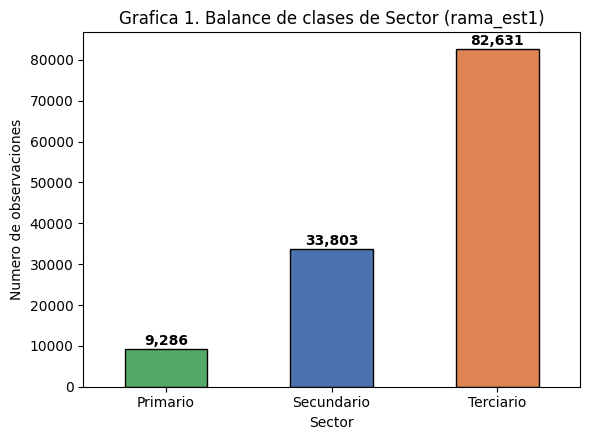

```python
import matplotlib.pyplot as plt
%matplotlib inline

fig, ax = plt.subplots(figsize=(6, 4.5))
orden = ['Primario', 'Secundario', 'Terciario']
colores = ['#55A868', '#4C72B0', '#DD8452']
conteo.reindex(orden).plot(kind='bar', color=colores, edgecolor='black', ax=ax)
ax.set_xticklabels(orden, rotation=0)
ax.set_ylabel('Numero de observaciones')
ax.set_title('Grafica 1. Balance de clases de Sector (rama_est1)')
for i, v in enumerate(conteo.reindex(orden)):
    ax.text(i, v + 1000, f"{v:,}", ha='center', fontweight='bold')
plt.tight_layout()
plt.show()
```

Aqui podemos ver el desbalance entre el terciario contra el secundario y primario

# Preparación y limpieza de datos

La limpieza aplica los mismos criterios que en el proyecto de clasificación de prestaciones laborales, donde se justifica cada paso: se eliminan los identificadores de la encuesta, las columnas vacías o con fuga de datos, la escolaridad no especificada y las horas trabajadas poco realistas.

```python
# Se eliminan las columnas que son identificadores de la encuesta (llave primaria y
# banderas de control), y p6c/n_hij (vienen vacia/con fuga de datos)
ids = ['r_def', 'c_res', 'cve_ent', 'con', 'upm', 'n_pro_viv',
       'v_sel', 'n_hog', 'h_mud', 'n_ren']
sub = sub.drop(columns=ids)
sub = sub.drop(columns=['p6c', 'n_hij'])

# Limpieza (mismos criterios que en el proyecto de prestaciones laborales)
sub = sub[sub['anios_esc'] != 99]                             # anios_esc no especificado
sub = sub[(sub['hrsocup'] <= 119) & (sub['hrsocup'] != 0)]    # horas trabajadas poco realistas

# Recodificacion y transformacion de variables
sub['sex01'] = sub['sex'].replace({1: 0, 2: 1})   # 0 = hombre, 1 = mujer
sub['ur01'] = sub['ur'].replace({1: 0, 2: 1})     # 0 = urbano, 1 = rural
sub['log_ingocup'] = np.log(sub['ingocup'])       # log de ingreso (para LDA)

print("Shape final tras limpieza:", sub.shape)
print(sub['Sector'].value_counts())
```

```
Shape final tras limpieza: (120430, 22)
Sector
Terciario     79025
Secundario    32355
Primario       9050
Name: count, dtype: int64
```

Quedan 120,430 observaciones y 22 columnas: se eliminaron las llaves y columnas innecesarias y se recodificaron algunas variables.

# Separación de datos y balance de clases

Se separan los datos en entrenamiento (80%) y prueba (20%), usando `stratify` para asegurar que la proporción de las 3 clases se mantenga igual en ambos subconjuntos ya que si la partición no fuera estratificada, se podría dar el caso de que una clase minoritaria quedara sub-representada en alguno de los dos subconjuntos, afectando la evaluación del modelo.

```python
from sklearn.model_selection import train_test_split

datos = sub[['eda', 'anios_esc', 'hrsocup', 'ingocup', 'log_ingocup',
             'sex01', 'ur01', 'rama_est1', 'Sector']].copy()

train, test = train_test_split(
    datos, train_size=0.8, random_state=67,
    stratify=datos['rama_est1']
)

print("Entrenamiento:", train.shape)
print("Prueba:       ", test.shape)

balance = pd.DataFrame({
    'Original': datos['Sector'].value_counts(normalize=True),
    'Entrenamiento': train['Sector'].value_counts(normalize=True),
    'Prueba': test['Sector'].value_counts(normalize=True)
}).round(4)
print()
print(balance)
```

```
Entrenamiento: (96344, 9)
Prueba:        (24086, 9)

            Original  Entrenamiento  Prueba
Sector
Terciario     0.6562         0.6562  0.6562
Secundario    0.2687         0.2687  0.2687
Primario      0.0751         0.0751  0.0751
```

Las proporciones son prácticamente idénticas en los 3 conjuntos (65.62% terciario / 26.87% secundario / 7.51% primario), tal como se esperaba con `stratify`. Se valida esto con una prueba ji-cuadrada, comparando los conteos (no las proporciones) de cada clase entre entrenamiento y prueba.

```python
from scipy.stats import chi2_contingency

conteos_split = pd.DataFrame({
    'Entrenamiento': train['Sector'].value_counts().sort_index(),
    'Prueba': test['Sector'].value_counts().sort_index()
})
print(conteos_split)

chi2, p_valor, dof, esperado = chi2_contingency(conteos_split.T)
print(f"\nchi2 = {chi2:.4f}")
print(f"p-value = {p_valor:.4f}")
```

```
            Entrenamiento  Prueba
Sector
Primario             7240    1810
Secundario          25884    6471
Terciario           63220   15805

chi2 = 0.0000
p-value = 1.0000
```

El p-value sale 1.0000, es decir, no hay evidencia de que la proporción de clases dependa de si una observación cayó en entrenamiento o en prueba. Esto es justo lo que se busca: si más adelante las métricas de validación cruzada (calculadas en entrenamiento) y las métricas de prueba difieren, va a ser por cómo generaliza el modelo, no porque los subconjuntos tengan una composición distinta.

# Modelo basado en LDA

## Selección de variables y revisión de supuestos

Como se mencionó en la metodología, LDA asume que las variables explicativas siguen (dentro de cada clase) una distribución aproximadamente normal, con la misma matriz de covarianza entre clases. De las variables disponibles, las que tiene sentido usar aquí son las **4 variables continuas**: `eda`, `anios_esc`, `hrsocup` y `log_ingocup` (ya transformada). Las variables `sex01` y `ur01` son binarias, claramente no normales, así que **no** se incluyen en el modelo de LDA (sí se usarán más adelante en el árbol, que no tiene este problema).

Antes de entrenar el modelo, revisemos qué tan razonables son los supuestos con estas 4 variables. Primero, la forma de la distribución de cada variable dentro de cada clase (¿se parece a una campana?).

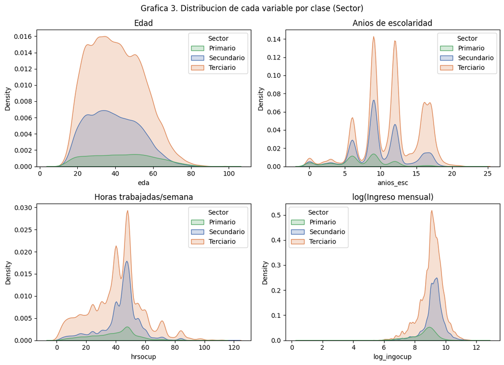

```python
import seaborn as sns

vars_lda = ['eda', 'anios_esc', 'hrsocup', 'log_ingocup']
nombres_lda = {'eda': 'Edad', 'anios_esc': 'Anios de escolaridad',
               'hrsocup': 'Horas trabajadas/semana', 'log_ingocup': 'log(Ingreso mensual)'}

fig, axes = plt.subplots(2, 2, figsize=(11, 8))
for ax, var in zip(axes.ravel(), vars_lda):
    sns.kdeplot(data=train, x=var, hue='Sector', hue_order=['Primario', 'Secundario', 'Terciario'],
                palette=['#55A868', '#4C72B0', '#DD8452'], fill=True, alpha=0.25, ax=ax)
    ax.set_title(nombres_lda[var])
plt.suptitle('Grafica 3. Distribucion de cada variable por clase (Sector)')
plt.tight_layout()
plt.show()
```

Ahora revisemos el segundo supuesto: **homocedasticidad**, es decir, que la matriz de covarianza de las 4 variables sea parecida entre las 3 clases. Una forma sencilla de revisar esto es comparar la desviación estándar de cada variable, calculada por separado en cada clase.

```python
print("Desviacion estandar por clase:")
print(train.groupby('Sector')[vars_lda].std().round(3))
print()
print("Promedio por clase:")
print(train.groupby('Sector')[vars_lda].mean().round(3))
```

```
Desviacion estandar por clase:
               eda  anios_esc  hrsocup  log_ingocup
Sector
Primario    16.703      3.881   15.811        0.914
Secundario  13.584      3.821   13.238        0.677
Terciario   14.074      4.082   17.841        0.761

Promedio por clase:
               eda  anios_esc  hrsocup  log_ingocup
Sector
Primario    43.249      7.287   39.230        8.570
Secundario  39.085      9.897   43.404        9.202
Terciario   40.376     11.363   40.884        9.075
```

**Sobre el promedio (qué tan distintas son las clases entre sí):**

- Primario tiene el promedio de edad más alto (43.2 años) y de escolaridad más bajo (7.3 años) — gente mayor y con menos estudios, consistente con trabajo de campo.
- Secundario y Terciario se parecen más entre sí en escolaridad (9.9 y 11.4 años) e ingreso, que es justo por qué el modelo los confunde tanto entre ellos.
- Secundario es el que más horas trabaja en promedio (43.4), un poco por encima de Terciario (40.9) y bastante por encima de Primario (39.2).
- Esto en general es buena señal: si los promedios fueran iguales entre clases, ninguna variable serviría para distinguir sectores.

Con estos supuestos revisados (razonablemente cumplidos, aunque no perfectamente), se procede a entrenar el modelo. Primero se estandarizan las variables (media 0, desviación estándar 1), esto es para facilitar ver y comparar variables despues

```python
from sklearn.preprocessing import StandardScaler

Xl_train = train[vars_lda]
Xl_test = test[vars_lda]
yl_train = train['rama_est1']
yl_test = test['rama_est1']

scaler = StandardScaler().fit(Xl_train)
Xl_train_s = pd.DataFrame(scaler.transform(Xl_train), columns=vars_lda, index=Xl_train.index)
Xl_test_s = pd.DataFrame(scaler.transform(Xl_test), columns=vars_lda, index=Xl_test.index)

print("Promedio tras estandarizar (train):")
print(Xl_train_s.mean().round(4))
print("\nDesviacion estandar tras estandarizar (train):")
print(Xl_train_s.std().round(4))
```

```
Promedio tras estandarizar (train):
eda           -0.0
anios_esc     -0.0
hrsocup       -0.0
log_ingocup   -0.0
dtype: float64

Desviacion estandar tras estandarizar (train):
eda            1.0
anios_esc      1.0
hrsocup        1.0
log_ingocup    1.0
dtype: float64
```

## Entrenamiento y visualización de las funciones discriminantes

Ahora sí, se entrena el modelo usando `LinearDiscriminantAnalysis` de `sklearn.discriminant_analysis`, con los datos de entrenamiento ya estandarizados. Como se tienen 3 clases y 4 variables, el modelo genera $\min(3-1, 4) = 2$ funciones discriminantes ($LD1$ y $LD2$), que se pueden usar para proyectar los datos a un plano y visualizar la separación entre clases.

```python
from sklearn.discriminant_analysis import LinearDiscriminantAnalysis as LDA

lda1 = LDA()
lda1.fit(Xl_train_s, yl_train)

print("Proporcion de varianza explicada por cada funcion discriminante:")
print(lda1.explained_variance_ratio_.round(4))
```

```
Proporcion de varianza explicada por cada funcion discriminante:
[0.6978 0.3022]
```

$LD1$ explica cerca del 70% de la varianza entre clases que logran capturar las 2 funciones discriminantes juntas, y $LD2$ el otro 30%. Es decir, la mayor parte de la separación entre sectores se puede resumir en una sola dimensión, pero $LD2$ comoquiera aporta lo demás que falta

Proyectemos las observaciones del set de prueba sobre este plano ($LD1$, $LD2$) y veamos por la clase real, para ver qué tan bien separa el modelo a los 3 sectores.

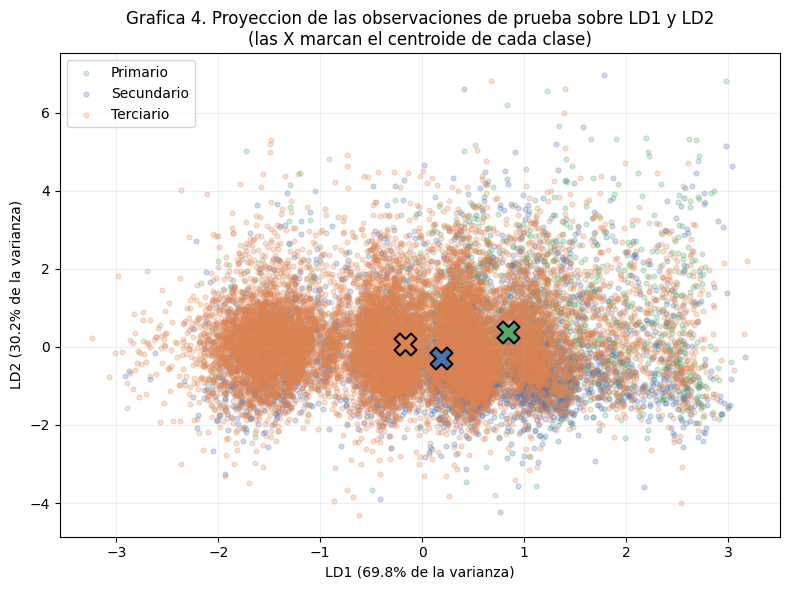

```python
proy_test = lda1.transform(Xl_test_s)
proy_df = pd.DataFrame(proy_test, columns=['LD1', 'LD2'])
proy_df['Sector'] = test['Sector'].values

fig, ax = plt.subplots(figsize=(8, 6))
colores_sector = {'Primario': '#55A868', 'Secundario': '#4C72B0', 'Terciario': '#DD8452'}
for sector, color in colores_sector.items():
    subconjunto = proy_df[proy_df['Sector'] == sector]
    ax.scatter(subconjunto['LD1'], subconjunto['LD2'], alpha=0.25, s=12,
               color=color, label=sector)

# Centroides de cada clase en el espacio proyectado
centroides = proy_df.groupby('Sector')[['LD1', 'LD2']].mean()
for sector, color in colores_sector.items():
    ax.scatter(centroides.loc[sector, 'LD1'], centroides.loc[sector, 'LD2'],
               color=color, edgecolor='black', s=250, marker='X', linewidth=1.5, zorder=5)

ax.set_xlabel(f'LD1 ({lda1.explained_variance_ratio_[0]*100:.1f}% de la varianza)')
ax.set_ylabel(f'LD2 ({lda1.explained_variance_ratio_[1]*100:.1f}% de la varianza)')
ax.set_title('Grafica 4. Proyeccion de las observaciones de prueba sobre LD1 y LD2\n(las X marcan el centroide de cada clase)')
ax.legend()
ax.grid(alpha=0.2)
plt.tight_layout()
plt.show()
```

Aqui podemos ver que hay una separación parcial, las clases si estan en posiciones diferentes en el plano y hay una tendencia de que las observaciones de Primario(verde) se concentren en valores mas positivos de LD1, mientras que Terciario(naranja) se acerca más hacia valores negativos, mientras que el azul que es secundario se queda más en medio.

Esto es consistente con que `anios_esc` tiene el coeficiente más grande en $LD1$ (ver más abajo) y primario es, por mucho, el sector con menos escolaridad promedio. Sin embargo, las 3 nubes de puntos se traslapan bastante entre sí, sobre todo entre secundario y terciario, lo que sugiere que una frontera lineal (que es justo lo que LDA puede generar) **no** va a lograr separar a la perfección estos 3 sectores usando nada más estas 4 variables continuas. Esto es consistente con lo que ya se sospechaba desde la revisión de la Gráfica 3: las distribuciones de las variables se traslapan bastante entre clases.

Veamos qué tanto pesa cada variable original en la construcción de $LD1$ y $LD2$ (los coeficientes de las funciones discriminantes, conocidos como *scalings*).

```python
scalings = pd.DataFrame(lda1.scalings_, index=vars_lda, columns=['LD1', 'LD2'])
print(scalings.round(4))
```

```
                LD1     LD2
eda         -0.1615  0.4315
anios_esc   -1.0308  0.4776
hrsocup      0.0611  0.0428
log_ingocup -0.1063 -1.0318
```

En $LD1$, la variable con mayor peso (por mucho, en valor absoluto) es `anios_esc` (-1.03), muy por encima de `eda` (-0.16) y `log_ingocup` (-0.11); `hrsocup` prácticamente no contribuye (0.06). Es decir, la primera función discriminante separa principalmente por escolaridad (entre más escolaridad, más negativo el valor de $LD1$, que es justo la dirección hacia donde se mueven secundario y terciario respecto a primario en la Gráfica 4). En $LD2$ la variable dominante cambia a `log_ingocup` (-1.03), acompañada de `anios_esc` y `eda` con signo positivo (0.48 y 0.43); `hrsocup` de nuevo aporta poco (0.04). Es decir, la segunda función discriminante contrasta el ingreso contra la escolaridad y la edad, un patrón más sutil que ayuda a distinguir secundario de terciario (dos sectores con escolaridad parecida pero perfiles de ingreso distintos).

## Efecto de las probabilidades a priori

Como estan desbalanceadas las clases, vamos a ver la diferencia entre los modelos de uno normal y otro usando priori

Primero vamos a usar el modelo original y ver las priori del modelo

```python
print("Probabilidades a priori usadas por el modelo (por default):")
print(pd.Series(lda1.priors_, index=lda1.classes_).round(4))
```

```
Probabilidades a priori usadas por el modelo (por default):
1    0.0751
2    0.2687
3    0.6562
dtype: float64
```

```python
from sklearn.metrics import (accuracy_score, f1_score, precision_score, recall_score,
                              confusion_matrix, classification_report)

pred1 = lda1.predict(Xl_test_s)

acc1 = accuracy_score(yl_test, pred1)
f1_1 = f1_score(yl_test, pred1, average='macro')

print(f"Exactitud: {acc1:.4f}")
print(f"F1-score macro: {f1_1:.4f}\n")
print(classification_report(yl_test, pred1, target_names=['Primario', 'Secundario', 'Terciario']))
```

```
Exactitud: 0.6531
F1-score macro: 0.3353

              precision    recall  f1-score   support

    Primario       0.33      0.07      0.12      1810
  Secundario       0.40      0.06      0.10      6471
   Terciario       0.67      0.96      0.79     15805

    accuracy                           0.65     24086
   macro avg       0.47      0.36      0.34     24086
weighted avg       0.57      0.65      0.55     24086
```

```python
cm1 = confusion_matrix(yl_test, pred1)
print("Matriz de confusion (filas = clase real, columnas = clase predicha):")
print(pd.DataFrame(cm1, index=['Primario', 'Secundario', 'Terciario'],
                    columns=['Primario', 'Secundario', 'Terciario']))
```

```
Matriz de confusion (filas = clase real, columnas = clase predicha):
            Primario  Secundario  Terciario
Primario         130         154       1526
Secundario        75         362       6034
Terciario        188         379      15238
```

- El modelo usa como priors las proporciones reales de tus datos: 7.5% primario, 26.9% secundario, 65.6% terciario (se confirma con el print de `lda1.priors_`).
- La exactitud sale en 65.3%, que a primera vista se ve bien.
- Pero viendo el reporte de clasificación, el recall (sensibilidad) por clase es muy desigual:
  - Primario: 7%
  - Secundario: 6%
  - Terciario: 96%
- O sea, el modelo casi siempre predice "terciario" y casi nunca las otras dos clases.
- Se confirma en la matriz de confusión: de las 1,810 observaciones reales de primario, solo 130 se clasifican bien; la mayoría (1,526) se van a terciario. Con secundario pasa algo parecido: de 6,471 reales, solo 362 se clasifican bien.
- El F1-score macro (que no le da ventaja a la clase grande) se desploma a 0.335, mucho más bajo que la exactitud, y refleja mejor lo que está pasando: el modelo no está aprendiendo a distinguir primario ni secundario, nada más está aprovechando que terciario es la mayoría.

El prior por default está "programando" al modelo para favorecer a terciario, así que hace falta corregirlo (siguiente paso: probar con priors uniformes).

```python
lda2 = LDA(priors=[1/3, 1/3, 1/3])
lda2.fit(Xl_train_s, yl_train)
pred2 = lda2.predict(Xl_test_s)

acc2 = accuracy_score(yl_test, pred2)
f1_2 = f1_score(yl_test, pred2, average='macro')

print(f"Exactitud: {acc2:.4f}")
print(f"F1-score macro: {f1_2:.4f}\n")
print(classification_report(yl_test, pred2, target_names=['Primario', 'Secundario', 'Terciario']))
```

```
Exactitud: 0.4929
F1-score macro: 0.4340

              precision    recall  f1-score   support

    Primario       0.18      0.58      0.27      1810
  Secundario       0.39      0.51      0.44      6471
   Terciario       0.78      0.48      0.59     15805

    accuracy                           0.49     24086
   macro avg       0.45      0.52      0.43     24086
weighted avg       0.63      0.49      0.53     24086
```

```python
cm2 = confusion_matrix(yl_test, pred2)
print("Matriz de confusion (priors uniformes):")
print(pd.DataFrame(cm2, index=['Primario', 'Secundario', 'Terciario'],
                    columns=['Primario', 'Secundario', 'Terciario']))
```

```
Matriz de confusion (priors uniformes):
            Primario  Secundario  Terciario
Primario        1044         499        267
Secundario      1285        3286       1900
Terciario       3546        4716       7543
```

- Con priors uniformes (1/3 para cada clase), la exactitud baja a 49.3% (contra el 65.3% de antes).
- Pero el recall por clase ahora queda mucho más parejo:
  - Primario: 58%
  - Secundario: 51%
  - Terciario: 48%
- Ya no hay una clase que domine sobre las demás como antes (7%/6%/96%), el modelo reparte sus aciertos de forma mucho más equilibrada entre las 3.
- En la matriz de confusión se ve el cambio: de las 1,810 observaciones reales de primario, ahora 1,044 se clasifican bien (antes eran solo 130). Con secundario pasa algo parecido: de 6,471 reales, ahora 3,286 se clasifican bien (antes 362).
- El costo de esto es que terciario empeora bastante: de 15,805 casos reales, ahora solo 7,543 se clasifican bien (antes eran 15,238), porque el modelo ya no lo favorece de entrada.
- El F1-score macro sube a 0.434 (contra 0.335 de antes), confirmando que el modelo mejora en general al tratar a las 3 clases por igual, aunque la exactitud total se vea más baja.

Vamos a usar mejor este modelo al otro aunque su exactitud es menor porque este modelo es mejor ya que no se basa en puro terciario

# Modelo basado en Árboles de Decisión

## Selección de variables y árbol inicial

A diferencia de LDA, un árbol de decisión no necesita que las variables cumplan ningún supuesto de distribución, así que aquí sí se pueden aprovechar las 2 variables categóricas que se dejaron fuera del modelo de LDA: `sex01` (sexo) y `ur01` (tipo de localidad, urbana o rural), además de las 4 variables continuas ya usadas (`eda`, `anios_esc`, `hrsocup`, `ingocup`, esta última **sin** transformación logarítmica, porque a un árbol no le afecta el sesgo de la distribución).

- `class_weight='balanced'`: para que el algoritmo le dé más peso, durante el entrenamiento, a las observaciones de las clases minoritarias (compensando el mismo desbalance que se vio en LDA).

Primero se entrena un árbol completamente sin restricciones (sin podar), solo para tener un punto de referencia y ver qué tan grave es el sobreajuste sin ningún control.

```python
from sklearn.tree import DecisionTreeClassifier as DTC

vars_tree = ['eda', 'anios_esc', 'hrsocup', 'ingocup', 'sex01', 'ur01']
Xt_train = train[vars_tree]
Xt_test = test[vars_tree]
yt_train = train['rama_est1']
yt_test = test['rama_est1']

tree0 = DTC(random_state=67, class_weight='balanced').fit(Xt_train, yt_train)
pred_t0 = tree0.predict(Xt_test)

acc_t0 = accuracy_score(yt_test, pred_t0)
f1_t0 = f1_score(yt_test, pred_t0, average='macro')

print(f"Exactitud: {acc_t0:.4f}")
print(f"F1-score macro: {f1_t0:.4f}")
print(f"Numero de hojas: {tree0.get_n_leaves()}")
print(f"Profundidad: {tree0.get_depth()}")
```

```
Exactitud: 0.6189
F1-score macro: 0.5126
Numero de hojas: 37424
Profundidad: 41
```

El árbol tiene **37,424 hojas** y una profundidad de **41 niveles**, un árbol grande e imposible de interpretar o de graficar de forma útil (y ni siquiera es el mejor en la métrica que interesa: F1 macro de 0.513, más adelante se compara contra la versión podada). Esto es sobreajuste: el árbol está memorizando particularidades del set de entrenamiento en vez de aprender un patrón, entonces tenemos que podarlo

## Poda del árbol (cost-complexity pruning)

Para encontrar el valor óptimo de $\alpha$ se usa validación cruzada de 4 folds (`StratifiedKFold`, para mantener la proporción de clases en cada fold), evaluando distintos valores de $\alpha$ y quedándose con el que da, en promedio, el mejor F1-score macro (no exactitud, por la misma razón de siempre: no queremos optimizar para ignorar a las clases chicas).

Por eficiencia computacional (entrenar un árbol completo, sin podar, sobre las 96,344 observaciones de entrenamiento, dentro de un ciclo de validación cruzada con muchos valores de $\alpha$, resulta muy lento), la búsqueda del valor óptimo de $\alpha$ se hace sobre una **submuestra estratificada de 25,000 observaciones** del set de entrenamiento. Una vez identificado el mejor $\alpha$, el árbol final sí se entrena con el set de entrenamiento completo.

```python
from sklearn.model_selection import StratifiedKFold, cross_val_score

Xt_sub, _, yt_sub, _ = train_test_split(
    Xt_train, yt_train, train_size=25000, random_state=67, stratify=yt_train
)

skf = StratifiedKFold(n_splits=4, shuffle=True, random_state=67)
ccp = np.linspace(0.00001, 0.004, 60)

cv_scores = []
for alpha in ccp:
    t = DTC(random_state=67, class_weight='balanced', ccp_alpha=alpha)
    cv_scores.append(np.mean(cross_val_score(t, Xt_sub, yt_sub, cv=skf, scoring='f1_macro')))
cv_scores = np.array(cv_scores)

alpha_optimo = ccp[np.argmax(cv_scores)]
print("Mejor alpha:", alpha_optimo)
print("Mejor F1 macro (CV):", cv_scores.max())
```

```
Mejor alpha: 0.00041576271186440685
Mejor F1 macro (CV): 0.5388025209412122
```

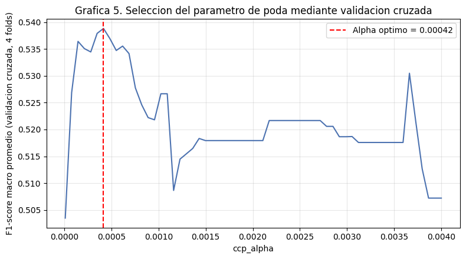

```python
fig, ax = plt.subplots(figsize=(8, 4.5))
ax.plot(ccp, cv_scores, color='#4C72B0')
ax.axvline(alpha_optimo, color='red', linestyle='--', label=f'Alpha optimo = {alpha_optimo:.5f}')
ax.set_xlabel('ccp_alpha')
ax.set_ylabel('F1-score macro promedio (validacion cruzada, 4 folds)')
ax.set_title('Grafica 5. Seleccion del parametro de poda mediante validacion cruzada')
ax.legend()
ax.grid(alpha=0.3)
plt.tight_layout()
plt.show()
```

Se ve el comportamiento esperado de cost-complexity pruning: con $\alpha$ muy chico (casi sin podar) el desempeño en validación cruzada no es el mejor posible (el árbol grande se sobreajusta incluso dentro de cada fold), el F1 macro sube rápidamente hasta un máximo alrededor de $\alpha \approx 0.0004$, y después empieza a bajar (y luego se aplana en escalones) conforme $\alpha$ sigue subiendo y el árbol se vuelve cada vez más pequeño y con menos capacidad de distinguir entre clases. El valor óptimo encontrado es $\alpha \approx 0.00042$.

## Árbol podado y evaluación

Con el valor óptimo de $\alpha$, se entrena el árbol final ya con todo el set

```python
pruned = DTC(random_state=67, class_weight='balanced', ccp_alpha=alpha_optimo).fit(Xt_train, yt_train)
pred_p = pruned.predict(Xt_test)

acc_p = accuracy_score(yt_test, pred_p)
f1_p = f1_score(yt_test, pred_p, average='macro')

print(f"Exactitud: {acc_p:.4f}")
print(f"F1-score macro: {f1_p:.4f}")
print(f"Numero de hojas: {pruned.get_n_leaves()}")
print(f"Profundidad: {pruned.get_depth()}")
```

```
Exactitud: 0.5935
F1-score macro: 0.5424
Numero de hojas: 39
Profundidad: 9
```

La diferencia es enorme: de 37,424 hojas y 41 niveles de profundidad se pasa a solo **39 hojas** y **9 niveles**, un árbol muchísimo más fácil de interpretar. Y, más importante, el F1-score macro en el set de prueba **mejora** (de 0.513 a 0.542) a pesar de que la exactitud baja un poco (de 61.9% a 59.3%)

Ahora vamos a graficar el arbol final ya podado

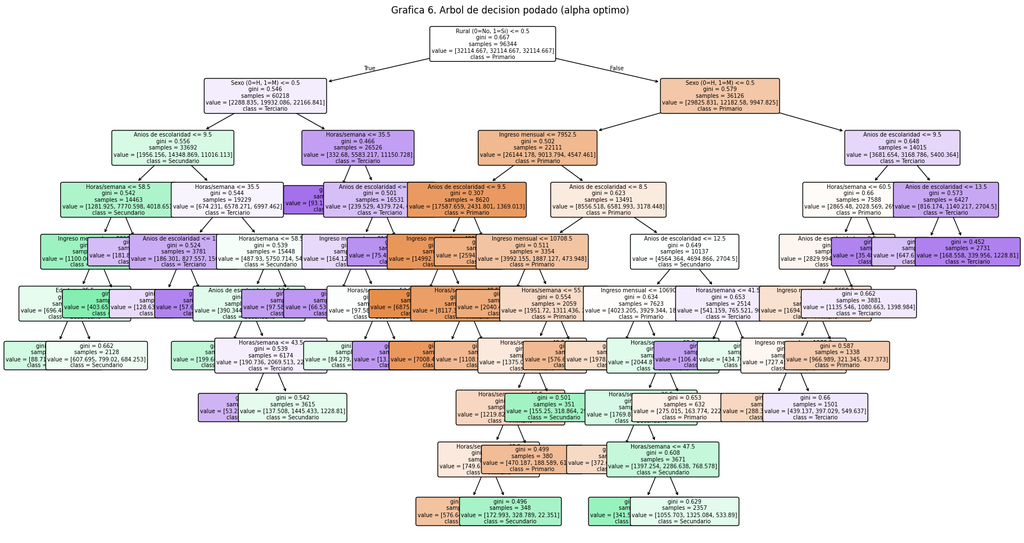

```python
from sklearn.tree import plot_tree

nombres_tree = ['Edad', 'Anios de escolaridad', 'Horas/semana', 'Ingreso mensual', 'Sexo (0=H, 1=M)', 'Rural (0=No, 1=Si)']

plt.figure(figsize=(22, 12))
plot_tree(pruned, filled=True, feature_names=nombres_tree,
          class_names=['Primario', 'Secundario', 'Terciario'],
          rounded=True, fontsize=7)
plt.title('Grafica 6. Arbol de decision podado (alpha optimo)')
plt.show()
```

Aunque con 39 hojas el árbol sigue siendo grande para revisarlo nodo por nodo, se alcanza a ver un patrón claro en los primeros niveles (los más importantes, porque afectan a más observaciones): la **primera separación** del árbol completo usa la variable de tipo de localidad (rural/urbana), y las siguientes separaciones importantes involucran sexo e ingreso. Esto sugiere que estas son las variables más relevantes para distinguir el sector económico, algo que se puede confirmar de forma más precisa con las importancias de variables del modelo.

```python
print(classification_report(yt_test, pred_p, target_names=['Primario', 'Secundario', 'Terciario']))
```

```
              precision    recall  f1-score   support

    Primario       0.34      0.78      0.47      1810
  Secundario       0.41      0.54      0.47      6471
   Terciario       0.82      0.60      0.69     15805

    accuracy                           0.59     24086
   macro avg       0.52      0.64      0.54     24086
weighted avg       0.67      0.59      0.61     24086
```

```python
cm_p = confusion_matrix(yt_test, pred_p)
print("Matriz de confusion (arbol podado):")
print(pd.DataFrame(cm_p, index=['Primario', 'Secundario', 'Terciario'],
                    columns=['Primario', 'Secundario', 'Terciario']))
```

```
Matriz de confusion (arbol podado):
            Primario  Secundario  Terciario
Primario        1411         204        195
Secundario      1137        3479       1855
Terciario       1638        4763       9404
```

- El árbol podado tiene una exactitud de 59% (24,086 casos de prueba).
- El recall (sensibilidad) por clase:
  - Primario: 78%
  - Secundario: 54%
  - Terciario: 60%
- A diferencia de LDA, aquí ninguna clase domina tanto sobre las demás — el árbol sí logra detectar bien a primario (78%), que era justo la clase que LDA casi ignoraba.
- La precisión es más despareja: Terciario tiene la más alta (0.82, cuando predice terciario casi siempre acierta), mientras que Primario (0.34) y Secundario (0.41) se equivocan más seguido cuando predicen esas clases.
- En la matriz de confusión:
  - De 1,810 casos reales de primario, 1,411 se clasifican bien (78%, coincide con el recall de arriba).
  - Secundario es el que más se confunde: de 6,471 reales, 1,855 se van a terciario y 1,137 se van a primario, solo 3,479 quedan bien clasificados.
  - Terciario también pierde bastantes casos hacia secundario: de 15,805 reales, 4,763 se clasifican como secundario.
- El F1-score macro es 0.54 (contra 0.43 de LDA con priors uniformes), así que el árbol le gana a LDA en esta métrica.
- La confusión más grande en todo el modelo es entre secundario y terciario (en ambas direcciones), justo los dos sectores más parecidos entre sí en escolaridad e ingreso, como ya se había visto desde la Gráfica 4 (LD1/LD2) y la Gráfica 3 (distribuciones traslapadas).

## Importancia de variables

Revisemos qué tanto contribuye cada variable a las decisiones del árbol podado, usando el atributo `feature_importances_` (basado en qué tanto reduce cada variable la impureza de Gini, ponderado por la cantidad de observaciones que pasan por cada separación donde se usa).

```python
importancias = pd.Series(pruned.feature_importances_, index=vars_tree).sort_values(ascending=False)
print(importancias.round(4))
```

```
ur01         0.5201
sex01        0.1734
ingocup      0.1425
anios_esc    0.0861
hrsocup      0.0755
eda          0.0024
dtype: float64
```

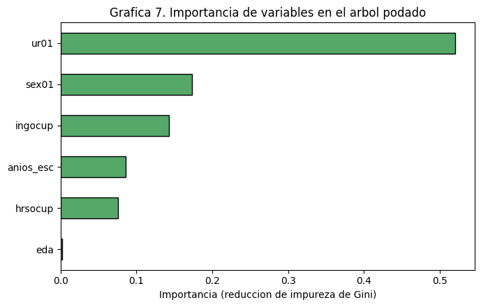

```python
fig, ax = plt.subplots(figsize=(7, 4.5))
importancias.sort_values().plot(kind='barh', color='#55A868', edgecolor='black', ax=ax)
ax.set_xlabel('Importancia (reduccion de impureza de Gini)')
ax.set_title('Grafica 7. Importancia de variables en el arbol podado')
plt.tight_layout()
plt.show()
```

Aqui podemos ver que la variable que más importa es la zona, si la persona vive en zona urbana o rural, que hace mucho sentido ya que estamos viendo en que sector trabaja una persona. Entonces si trabaja en el campo claro que tiene que ver si vive en una zona rural, despues es sexo, ingreso mensual, años de escuela y horas de ocupación. Todos estos tienen mucho sentido que tengan que ver con la sección de trabajo en donde estan

# Evaluación y comparación de los modelos

Para que la comparación sea justa, se usa la versión de LDA con probabilidades a priori uniformes (la que se decidió usar como final, dado el desbalance de clases) contra el árbol podado con `class_weight='balanced'`, ya que ambos ajustes buscan lo mismo: que el modelo no ignore a las clases minoritarias.

```python
resumen = pd.DataFrame({
    'LDA (priors uniformes)': [
        accuracy_score(yl_test, pred2),
        precision_score(yl_test, pred2, average='macro'),
        recall_score(yl_test, pred2, average='macro'),
        f1_score(yl_test, pred2, average='macro')
    ],
    'Decision tree (class_weight=balanced)': [
        accuracy_score(yt_test, pred_p),
        precision_score(yt_test, pred_p, average='macro'),
        recall_score(yt_test, pred_p, average='macro'),
        f1_score(yt_test, pred_p, average='macro')
    ]
}, index=['Exactitud', 'Precision (macro)', 'Sensibilidad (macro)', 'F1-score (macro)'])

print(resumen.round(4))
```

```
                      LDA (priors uniformes)  \
Exactitud                             0.4929
Precision (macro)                     0.4470
Sensibilidad (macro)                  0.5206
F1-score (macro)                      0.4340

                      Decision tree (class_weight=balanced)
Exactitud                                            0.5935
Precision (macro)                                    0.5233
Sensibilidad (macro)                                 0.6374
F1-score (macro)                                     0.5424
```

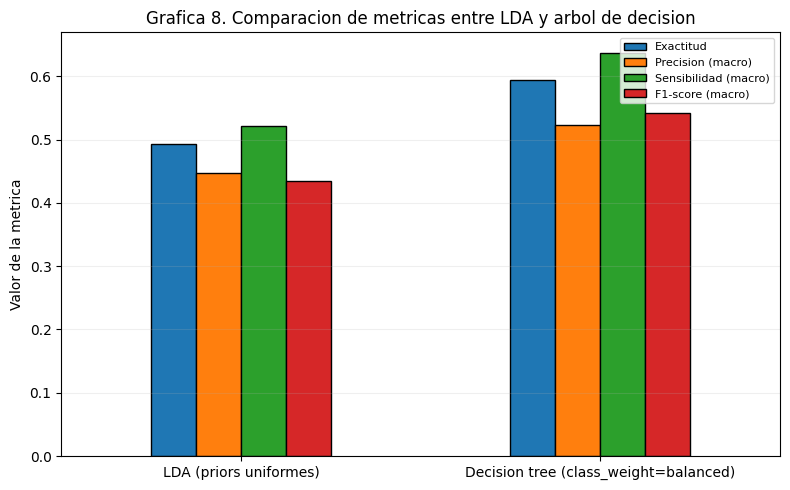

```python
fig, ax = plt.subplots(figsize=(8, 5))
resumen.T.plot(kind='bar', ax=ax, edgecolor='black')
ax.set_ylabel('Valor de la metrica')
ax.set_title('Grafica 8. Comparacion de metricas entre LDA y arbol de decision')
ax.set_xticklabels(resumen.columns, rotation=0)
ax.legend(loc='upper right', fontsize=8)
ax.grid(alpha=0.2, axis='y')
plt.tight_layout()
plt.show()
```

A simple vista, el árbol de decisión supera a LDA en las cuatro métricas.

### Coherencia entre las visualizaciones y las métricas

Este resultado es completamente coherente con lo que ya se había observado en las visualizaciones de cada modelo. La Gráfica 4 (proyeccion LD1 a LD2) mostraba un traslape considerable entre las 3 clases, sobre todo entre secundario y terciario, lo cual anticipaba que una frontera lineal no iba a lograr una separación limpia. Y la Grafica 7 (importancia de variables del arbol) mostró que la variable más util para distinguir sectores (`ur01`, tipo de localidad) es justo una variable categórica que LDA no puede usar por sus supuestos. No es casualidad que el modelo con acceso a esa variable tenga mejor desempeño.

### Influencia de los supuestos del modelo en su desempeño

Ya se había detectado, al revisar los supuestos de LDA, que la homocedasticidad no se cumple perfectamente (la varianza de `eda` y `hrsocup` son diferentes entre clases), y que ninguna variable disponible logra separar a las 3 clases de forma perfectamente limpia. Pero el factor más determinante no fue tanto la violación de los supuestos estadísticos de LDA en sí, sino una limitación más básica: LDA solo puede usar variables continuas razonablemente normales, y la variable más informativa de todo el problema (tipo de localidad) es binaria. Este es un buen ejemplo de cómo, más allá de que tan "bien" se ajuste un modelo a sus propios supuestos, la capacidad de un método para **usar toda la información disponible** puede ser el factor que más pese en el desempeño final.

### Ventajas y limitaciones de cada enfoque

**LDA:**

- Ventaja: genera funciones discriminantes interpretables (se puede ver exactamente qué combinación lineal de variables separa a las clases, y visualizar esa separación en 2D con 3 clases)
- Limitación: solo puede usar variables continuas que cumplan (al menos aproximadamente) sus supuestos de normalidad y homocedasticidad, lo cual, en este problema, lo dejó fuera de la variable más útil de todas (tipo de localidad). Además, es sensible a cómo se definen las probabilidades a priori cuando las clases están desbalanceadas.

**Árbol de decisión:**

- Ventaja: no necesita ningun supuesto sobre la distribución de las variables, puede mezclar variables continuas y categoricas sin transformación adicional, y es muy fácil de interpretar visualmente (al menos en sus primeros niveles). En este problema, esta flexibilidad fue decisiva.
- Limitación: sin podar, se sobreajusta de forma severa (se vio con el árbol de 37,424 hojas), así que requiere un paso adicional que es podarlo usando el mejor alfa para ser útil. Y, aun podado, sigue siendo un modelo relativamente inestable: pequeños cambios en los datos de entrenamiento podrían generar un árbol bastante distinto, algo que no le pasa a LDA.

# Reflexión y Conclusiones

El objetivo de este reporte era construir y comparar dos modelos de clasificación, uno basado en LDA y otro en árboles de decisión, para predecir el sector de actividad económica (primario, secundario o terciario) de una persona ocupada en México, usando datos de la ENOE.

En conclusión, la decisión entre LDA y decision tree, la gana decision tree porque supero a LDA en 4 metricas, las cuales son exactitud, precision, sensibilidad y F1-score macro, y la explicación es que no es que LDA esté "mal ajustado", sino que el árbol pudo usar una variable categórica (tipo de localidad) que resultó ser la más informativa de todo el problema, y que LDA no puede usar por construcción.

Entonces para este problema específico, el **decision tree es el modelo más adecuado**. Ya que F1-score macro de 0.542 contra 0.434 de LDA, con ventaja en las 4 métricas, y la evidencia cualitativa hay que tomarla en cuenta ya que: la variable más determinante para ver el sector económico de una persona es si vive en una zona rural o urbana, una variable categórica que solo el árbol pudo aprovechar.

# Referencias

- INEGI (2026). *Encuesta Nacional de Ocupación y Empleo (ENOE), primer trimestre de 2026*. Microdatos. Instituto Nacional de Estadística y Geografía. https://www.inegi.org.mx/programas/enoe/15ymas/
- INEGI. *Encuesta Nacional de Ocupación y Empleo. Diccionario de datos, SDEMT225*. https://www.inegi.org.mx/rnm/index.php/catalog/1121/data-dictionary/F42?file_name=SDEMT225
- INEGI. *Conociendo la base de datos de la ENOE* (descripción de las variables `ambito2` y `tue1`). https://www.inegi.org.mx/contenidos/productos/prod_serv/contenidos/espanol/bvinegi/productos/metodologias/est/702825001357.pdf